# Exploratory Data Analysis on Titanic Dataset

(DATA ANALYSIS and VISUALIZATION)

```python
import pandas as pd
import matplotlib.pyplot as plt
import seaborn as sns

# Optional for better plot style
sns.set_style("whitegrid")

# Load the dataset
df = pd.read_csv("train.csv")

# Display the first few rows
df.head()
```

|  | PassengerId | Survived | Pclass | Name | Sex | Age | SibSp | Parch | Ticket | Fare | Cabin | Embarked |
| --- | --- | --- | --- | --- | --- | --- | --- | --- | --- | --- | --- | --- |
| 0 | 1 | 0 | 3 | Braund, Mr. Owen Harris | male | 22.0 | 1 | 0 | A/5 21171 | 7.2500 | NaN | S |
| 1 | 2 | 1 | 1 | Cumings, Mrs. John Bradley (Florence Briggs Th... | female | 38.0 | 1 | 0 | PC 17599 | 71.2833 | C85 | C |
| 2 | 3 | 1 | 3 | Heikkinen, Miss. Laina | female | 26.0 | 0 | 0 | STON/O2. 3101282 | 7.9250 | NaN | S |
| 3 | 4 | 1 | 1 | Futrelle, Mrs. Jacques Heath (Lily May Peel) | female | 35.0 | 1 | 0 | 113803 | 53.1000 | C123 | S |
| 4 | 5 | 0 | 3 | Allen, Mr. William Henry | male | 35.0 | 0 | 0 | 373450 | 8.0500 | NaN | S |

# Titanic Dataset - Initial Data Exploration

We have loaded the Titanic dataset to begin our exploratory analysis.  
This dataset contains details about passengers on the Titanic and their survival.

```python
# Check for missing values in the dataset
df.isnull().sum()
```

```
PassengerId      0
Survived         0
Pclass           0
Name             0
Sex              0
Age            177
SibSp            0
Parch            0
Ticket           0
Fare             0
Cabin          687
Embarked         2
dtype: int64
```

## Handling Missing Values

First, we checked the missing values across the dataset.  
Here is how we handled them:

- Filled missing `Age` with the median of the `Age` column.
- Filled missing `Embarked` with the most frequent value (mode).
- Dropped the `Cabin` column due to high missing values.

```python
# Fill missing 'Age' with median
df['Age'] = df['Age'].fillna(df['Age'].median())

# Fill missing 'Embarked' with mode
df['Embarked'] = df['Embarked'].fillna(df['Embarked'].mode()[0])

# Check if 'Cabin' column exists before dropping
if 'Cabin' in df.columns:
    df = df.drop(columns=['Cabin'])

# Check the dataset after handling missing values
df.isnull().sum()
```

[output not shown]

We handled missing data by:

- Filling missing `Age` values with the median value.
- Filling missing `Embarked` values with the mode.
- Dropping the `Cabin` column due to a large number of missing values.

```python
# Basic information about the dataset
df.info()

# Statistical summary
df.describe()
```

```
<class 'pandas.core.frame.DataFrame'>
RangeIndex: 891 entries, 0 to 890
Data columns (total 11 columns):
 #   Column       Non-Null Count  Dtype
---  ------       --------------  -----
 0   PassengerId  891 non-null    int64
 1   Survived     891 non-null    int64
 2   Pclass       891 non-null    int64
 3   Name         891 non-null    object
 4   Sex          891 non-null    object
 5   Age          891 non-null    float64
 6   SibSp        891 non-null    int64
 7   Parch        891 non-null    int64
 8   Ticket       891 non-null    object
 9   Fare         891 non-null    float64
 10  Embarked     891 non-null    object
dtypes: float64(2), int64(5), object(4)
memory usage: 76.7+ KB
```

|  | PassengerId | Survived | Pclass | Age | SibSp | Parch | Fare |
| --- | --- | --- | --- | --- | --- | --- | --- |
| count | 891.000000 | 891.000000 | 891.000000 | 891.000000 | 891.000000 | 891.000000 | 891.000000 |
| mean | 446.000000 | 0.383838 | 2.308642 | 29.361582 | 0.523008 | 0.381594 | 32.204208 |
| std | 257.353842 | 0.486592 | 0.836071 | 13.019697 | 1.102743 | 0.806057 | 49.693429 |
| min | 1.000000 | 0.000000 | 1.000000 | 0.420000 | 0.000000 | 0.000000 | 0.000000 |
| 25% | 223.500000 | 0.000000 | 2.000000 | 22.000000 | 0.000000 | 0.000000 | 7.910400 |
| 50% | 446.000000 | 0.000000 | 3.000000 | 28.000000 | 0.000000 | 0.000000 | 14.454200 |
| 75% | 668.500000 | 1.000000 | 3.000000 | 35.000000 | 1.000000 | 0.000000 | 31.000000 |
| max | 891.000000 | 1.000000 | 3.000000 | 80.000000 | 8.000000 | 6.000000 | 512.329200 |

## Dataset Summary

```python
# Display value counts for key categorical features
df['Sex'].value_counts(), df['Embarked'].value_counts(), df['Pclass'].value_counts()
```

```
(Sex
 male      577
 female    314
 Name: count, dtype: int64,
 Embarked
 S    646
 C    168
 Q     77
 Name: count, dtype: int64,
 Pclass
 3    491
 1    216
 2    184
 Name: count, dtype: int64)
```

## Categorical Data Distribution

- The `Sex` feature shows more males than females.
- The most common embarkation port is 'S' (Southampton).
- The dataset contains passengers across three classes, with the majority in 3rd class.

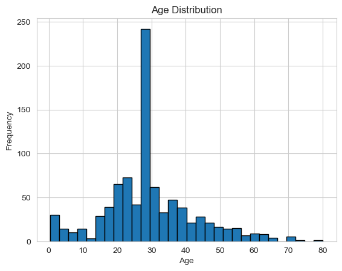

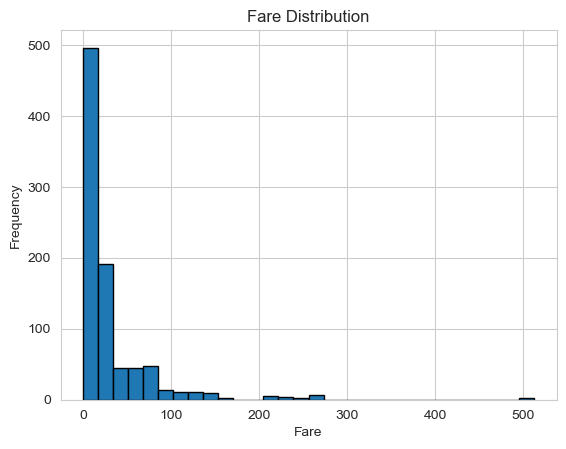

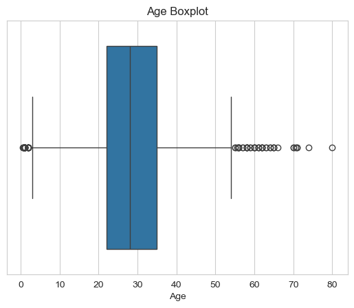

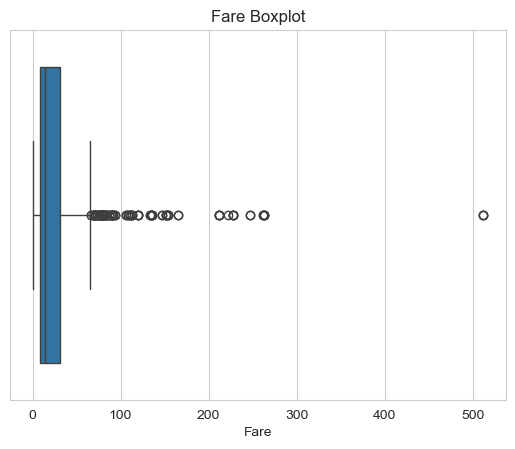

```python
# Age Distribution Histogram
df['Age'].hist(bins=30, edgecolor='black')
plt.title('Age Distribution')
plt.xlabel('Age')
plt.ylabel('Frequency')
plt.show()

# Fare Distribution Histogram
df['Fare'].hist(bins=30, edgecolor='black')
plt.title('Fare Distribution')
plt.xlabel('Fare')
plt.ylabel('Frequency')
plt.show()

# Boxplot for Age
sns.boxplot(x=df['Age'])
plt.title('Age Boxplot')
plt.show()

# Boxplot for Fare
sns.boxplot(x=df['Fare'])
plt.title('Fare Boxplot')
plt.show()
```

## Visualizing Data Distributions

- Age and Fare distributions reveal that:
  - Age is mostly between 20 and 40 years.
  - Fare is right-skewed, with some passengers paying very high fares.
  - Outliers are present in both `Age` and `Fare`.

Boxplots show a few extreme outliers in both age and fare.

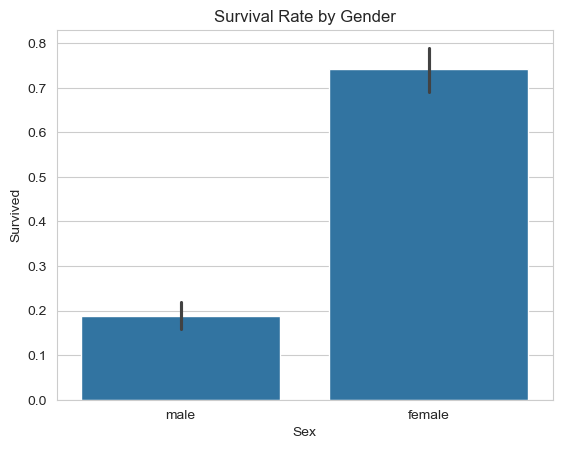

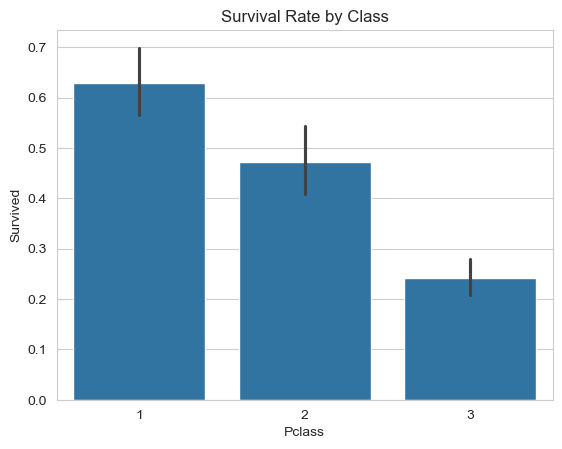

```python
# Survival Rate by Gender
sns.barplot(x='Sex', y='Survived', data=df)
plt.title('Survival Rate by Gender')
plt.show()

# Survival Rate by Class
sns.barplot(x='Pclass', y='Survived', data=df)
plt.title('Survival Rate by Class')
plt.show()
```

## Survival Rates by Gender and Class

- Females had a significantly higher survival rate compared to males.
- First-class passengers had the highest survival rate, while 3rd class passengers had the lowest survival.

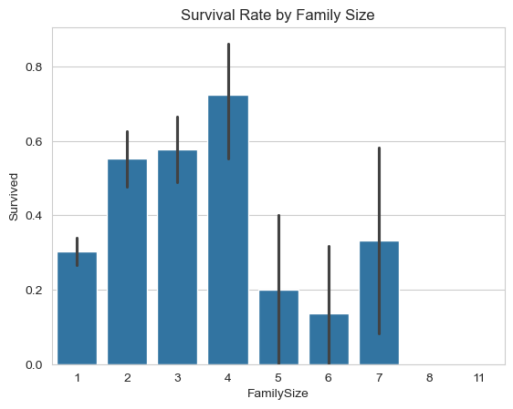

```python
# Creating a new feature: Family Size
df['FamilySize'] = df['SibSp'] + df['Parch'] + 1

# Visualizing Survival by Family Size
sns.barplot(x='FamilySize', y='Survived', data=df)
plt.title('Survival Rate by Family Size')
plt.show()
```

## Feature Engineering – Family Size

[figure not shown]

```python
# Convert categorical columns to numeric
df['Sex'] = df['Sex'].map({'male': 0, 'female': 1})
df['Embarked'] = df['Embarked'].map({'S': 0, 'C': 1, 'Q': 2})

# Select only numeric columns for correlation
numeric_columns = df.select_dtypes(include=['float64', 'int64']).columns

# Correlation with target 'Survived'
corr = df[numeric_columns].corr()

# Plot the correlation heatmap
sns.heatmap(corr[['Survived']].sort_values(by='Survived', ascending=False), annot=True, cmap='coolwarm')
plt.title('Correlation with Survival')
plt.show()
```

## Conclusion

- We have cleaned and explored the Titanic dataset to uncover key patterns.
- Gender, class, and fare are the most important features influencing survival.
- Family size can be an interesting feature for predictive modeling.